# COVID-19 - Study about mortality in the US

Statistical computation and visualization (MATH-517)

Zineb AGNAOU

Fahim BECK

Salima JAOUA

Matias JANVIN

Seorim PARK

October 26, 2021

[figure not shown]

## Data

In this project, several datasets were used to answer our questions. Each one of them refers to the same population (the US). Here are more specific descriptions.

### US deaths within categories and states

The first dataset we use is about [provisional COVID–19 deaths by place of death and age](https://data.cdc.gov/NCHS/Provisional-COVID-19-Deaths-by-Place-of-Death-and-/4va6-ph5s) from the CDC in the US. A complete description of it is available on the web page.

The variables we used in this project are : `Group`, `Year`, `Month`, `HHS Region`, `State`, `Place of Death`, `Age group`, `COVID-19 Deaths` and `Total Deaths`. What is particular here is that the sum of `COVID-19 Deaths` is not the total number of deaths in the US. Actually, we need to filter our data by `Group`, `State`, `Place of Death` and `Age Group` in order to get what we want.

A last thing we should take into account is that those numbers of deaths are not the exact number that happened during a given period. The reason is that there is always a lag in time (usually 1 to 8 weeks) between the instant when the death occurred and between when the death certificate is completed and submitted for reporting purposes.

## Packages

Here are some packages used in our project. Make sure they are installed before running the R Markdown file. Since the format of this Markdown is not standard, you need to install the *Distill* package. Instructions can be found on [Github](https://github.com/rstudio/distill).

```r
library(readr)
library(dplyr) # Useful for reading variables containing spaces
library(ggplot2)
library(reshape)
library(stringr) # Labels overlap
library(scales) # Labels value format
library(usmap)
```

## Risk factors

In this section, we will have a closer look at the risk factors of death from COVID–19. More particularly, we will first consider age and second the place where death occured.

### Age group

Here are deaths per age group since the beginning of the pandemic.

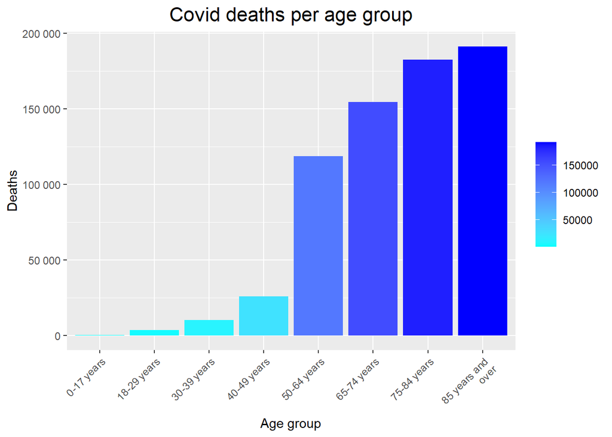

Older people are those who died the most as expected. The same barplot is available by month in an interactive web app. You can access it by clicking [here](https://fahimbeck.shinyapps.io/barplot_app/). By moving the slider, we are always able to observe a right-increase tendency on the barplots. We are also able to identify each wave.

### Place of death

Here are deaths per place of death since the beginning of the pandemic.

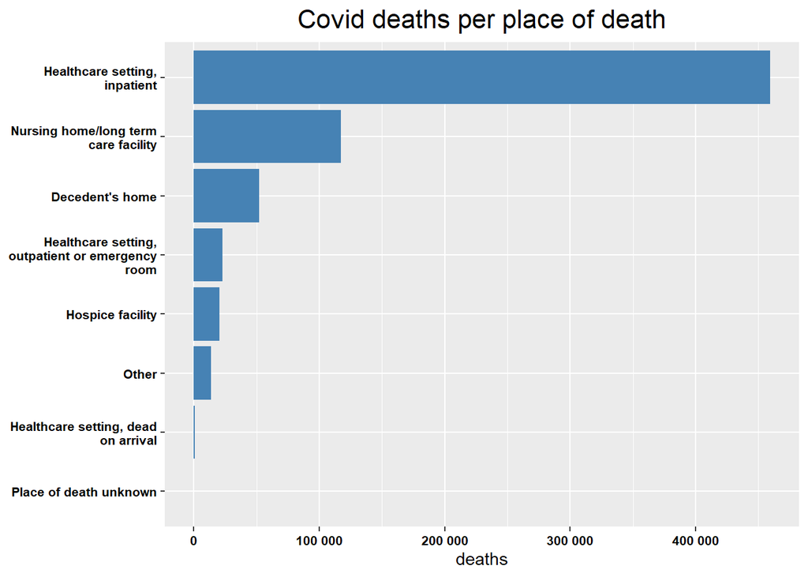

Here we can clearly see that most people were inpatients in a healthcare setting before dying. This includes ICUs and reflects our expectations. Then, people in nursing homes died also a lot as expected (older people being at risk), but much less than the previous category.